# NHL: Conner McDavid Predictions

# Grab 12 players that are closest to Conner McDavid.

```python
comb = comb.sort('SScore')
sim = comb[comb['SScore'] > 99.94]

# table of players that are similar to Conner
print((sim['Name']))
```

```
5198         PATRICK KANE
2097        PAVEL DATSYUK
3162          PHIL KESSEL
229        PETER FORSBERG
2222     ALEXANDER SYOMIN
2751          DOUG WEIGHT
1628         CHRIS KUNITZ
996          ANZE KOPITAR
7165          TAYLOR HALL
1893          MARC SAVARD
1639         RYAN GETZLAF
69      HENRIK ZETTERBERG
8756       CONNER MCDAVID
Name: Name, dtype: object
```

```python
sim.describe()
```

|  | PlayerId | SeasonEnding | GamesPlayed | GoalsPerGame | AssistsPerGame | TotalPointsPerGame | Age | Goals | Assists | x | y | SScore |
| --- | --- | --- | --- | --- | --- | --- | --- | --- | --- | --- | --- | --- |
| count | 13.000000 | 13.000000 | 13.000000 | 13.000000 | 13.000000 | 13.000000 | 13.000000 | 13.000000 | 13.000000 | 13.000000 | 13.000000 | 13.000000 |
| mean | 24654.692308 | 2011.384615 | 45.461538 | 0.362855 | 0.724308 | 1.087163 | 27.538462 | 16.461538 | 32.769231 | -7.915148 | -0.148026 | 99.964016 |
| std | 62171.941780 | 3.948385 | 2.401922 | 0.085388 | 0.077436 | 0.125151 | 5.092730 | 3.907586 | 1.739437 | 0.019938 | 0.023937 | 0.018326 |
| min | 285.000000 | 2004.000000 | 39.000000 | 0.212766 | 0.625000 | 0.893617 | 18.000000 | 10.000000 | 30.000000 | -7.936577 | -0.201972 | 99.943950 |
| 25% | 8523.000000 | 2013.000000 | 45.000000 | 0.319149 | 0.680851 | 1.042553 | 25.000000 | 15.000000 | 32.000000 | -7.931435 | -0.165920 | 99.951420 |
| 50% | 8615.000000 | 2013.000000 | 45.000000 | 0.355556 | 0.711111 | 1.083333 | 27.000000 | 16.000000 | 32.000000 | -7.920191 | -0.140080 | 99.960984 |
| 75% | 8793.000000 | 2013.000000 | 47.000000 | 0.422222 | 0.733333 | 1.113636 | 33.000000 | 19.000000 | 34.000000 | -7.906327 | -0.129388 | 99.966407 |
| max | 231200.000000 | 2016.000000 | 48.000000 | 0.489362 | 0.948718 | 1.410256 | 34.000000 | 23.000000 | 37.000000 | -7.869781 | -0.124295 | 100.000000 |

Interesting note: Conner McDavid played like a 27 year old even though he was only 18.

# Interactive Bokeh plot of t-SNE

```python
tmp = sim

_tools = 'box_zoom,pan,save,resize,reset,tap,wheel_zoom'
fig = figure(tools=_tools, title='t-SNE of Players', responsive=True,
             x_axis_label='Component 1', y_axis_label='Component 2')

source = ColumnDataSource(tmp)
source2 = ColumnDataSource(CM)
hover = HoverTool()
hover.tooltips=[('Player, Age, % Similar','@Name, @Age, @SScore%'),]
fig.scatter(tmp['x'], tmp['y'], source=source, size=8, alpha=0.6,
            line_color='grey', fill_color='grey')

fig.scatter(CM.x, CM.y, source=source2, size=8, alpha=0.6,
            line_color='blue', fill_color='blue')
fig.add_tools(hover)

show(fig)
```

[interactive chart not shown]

`<Bokeh Notebook handle for In[121]>`

# Grab those players similar to Conner McDavid, plot their full stats.

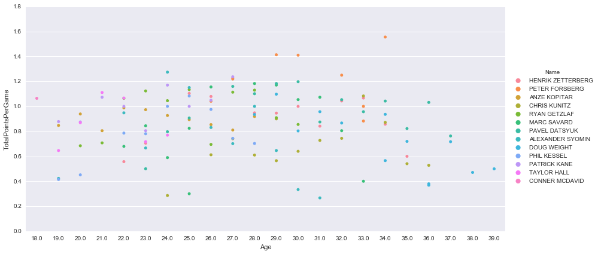

```python
name = sim['Name']
df_sim = df.loc[df['Name'].isin(name)]
a = sns.factorplot(data=df_sim, x='Age', y='TotalPointsPerGame', hue='Name', size=6, aspect=2, kind ='strip')

#sns.pairplot(sim, x_vars=['Age'], y_vars=['logTPPG'], size=7, aspect=0.7, kind='reg')
```

# Interactive Age vs Total Points Per Game

```python
tmp = df_sim

_tools = 'box_zoom,pan,save,resize,reset,tap,wheel_zoom'
fig = figure(tools=_tools, title='Age vs Total Points Per Game', responsive=True,
             x_axis_label='Age', y_axis_label='Total Points Per Game')

source = ColumnDataSource(tmp)
source2 = ColumnDataSource(CM)
hover = HoverTool()
hover.tooltips=[('Player, Age, % Similar','@Name, @Age, @SScore%'),]
fig.scatter(tmp['Age'], tmp['TotalPointsPerGame'], source=source, size=8, alpha=0.6,
            line_color='grey', fill_color = 'white')

fig.scatter(CM.Age, CM.TotalPointsPerGame, source=source2, size=8, alpha=0.6,
            line_color='blue', fill_color='blue')
fig.add_tools(hover)

show(fig)
```

[interactive chart not shown]

`<Bokeh Notebook handle for In[123]>`

# Prediction

Use those player stats to predict Conner's

```
1. reg1: Linear for comparison
2. reg2: What I think the distribution should be.
3. reg3: Maybe to incorporate the sophmore slump?
```

# Model 1: Just using Player's most simliar seasons to Conner's Rookie Season

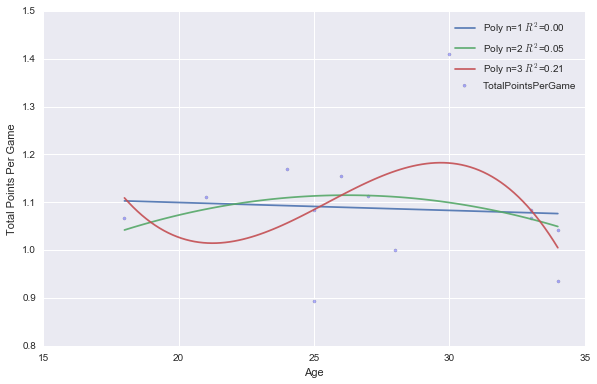

```python
reg11 = smf.ols('TotalPointsPerGame ~ Age', data=sim).fit()
reg21 = smf.ols('TotalPointsPerGame ~ Age + I(Age **2)', data=sim).fit()
reg31 = smf.ols('TotalPointsPerGame ~ Age + I(Age **2) + I(Age **3)', data=sim).fit()

plt.figure(figsize=(6 * 1.618, 6))
plt.scatter(sim.Age, sim.TotalPointsPerGame, s=10, alpha=0.3)
plt.xlabel('Age')
plt.ylabel('Total Points Per Game')

x = pd.DataFrame({'Age': np.linspace(sim.Age.min(), sim.Age.max(), 100)})

plt.plot(x, reg11.predict(x), label='Poly n=1 $R^2$=%.2f' % reg11.rsquared, alpha=0.9)
plt.plot(x, reg21.predict(x), label='Poly n=2 $R^2$=%.2f' % reg21.rsquared, alpha=0.9)
plt.plot(x, reg31.predict(x), label='Poly n=3 $R^2$=%.2f' % reg31.rsquared, alpha=0.9)
plt.legend()
```

```python
reg21.summary()
```

OLS Regression Results

| Dep. Variable: | TotalPointsPerGame | R-squared: | 0.053 |
| --- | --- | --- | --- |
| Model: | OLS | Adj. R-squared: | -0.136 |
| Method: | Least Squares | F-statistic: | 0.2795 |
| Date: | Thu, 01 Sep 2016 | Prob (F-statistic): | 0.762 |
| Time: | 14:31:20 | Log-Likelihood: | 9.4447 |
| No. Observations: | 13 | AIC: | -12.89 |
| Df Residuals: | 10 | BIC: | -11.19 |
| Df Model: | 2 |  |  |
| Covariance Type: | nonrobust |  |  |

|  | coef | std err | t | P>\|t\| | [95.0% Conf. Int.] |
| --- | --- | --- | --- | --- | --- |
| Intercept | 0.3734 | 1.083 | 0.345 | 0.737 | -2.039 2.786 |
| Age | 0.0566 | 0.082 | 0.692 | 0.505 | -0.126 0.239 |
| I(Age ** 2) | -0.0011 | 0.002 | -0.715 | 0.491 | -0.004 0.002 |

| Omnibus: | 7.106 | Durbin-Watson: | 2.450 |
| --- | --- | --- | --- |
| Prob(Omnibus): | 0.029 | Jarque-Bera (JB): | 3.431 |
| Skew: | 0.811 | Prob(JB): | 0.180 |
| Kurtosis: | 4.924 | Cond. No. | 2.43e+04 |

```python
# B + Age(AgeC) + I(Age(Age2C) **2)
B = 0.3734
AgeC = 0.0566
Age2C = -0.0011


for age in range(18,32):
    y = B + AgeC*(age) + (Age2C*((age**2)))
    print('When Conner is Age %d, his TPPG will be: %s' % (age, y))
```

```
When Conner is Age 18, his TPPG will be: 1.0357999999999998
When Conner is Age 19, his TPPG will be: 1.0516999999999999
When Conner is Age 20, his TPPG will be: 1.0654
When Conner is Age 21, his TPPG will be: 1.0768999999999997
When Conner is Age 22, his TPPG will be: 1.0861999999999998
When Conner is Age 23, his TPPG will be: 1.0932999999999997
When Conner is Age 24, his TPPG will be: 1.0981999999999998
When Conner is Age 25, his TPPG will be: 1.1009
When Conner is Age 26, his TPPG will be: 1.1014
When Conner is Age 27, his TPPG will be: 1.0997
When Conner is Age 28, his TPPG will be: 1.0957999999999999
When Conner is Age 29, his TPPG will be: 1.0897000000000001
When Conner is Age 30, his TPPG will be: 1.0814
When Conner is Age 31, his TPPG will be: 1.0709
```

# Model 2: Using all Historical Data from Players similar to Conner McDavid

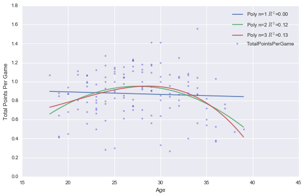

```python
reg1 = smf.ols('TotalPointsPerGame ~ Age', data=df_sim).fit()
reg2 = smf.ols('TotalPointsPerGame ~ Age + I(Age **2)', data=df_sim).fit()
reg3 = smf.ols('TotalPointsPerGame ~ Age + I(Age **2) + I(Age **3)', data=df_sim).fit()

plt.figure(figsize=(6 * 1.618, 6))
plt.scatter(df_sim.Age, df_sim.TotalPointsPerGame, s=10, alpha=0.3)
plt.xlabel('Age')
plt.ylabel('Total Points Per Game')

x = pd.DataFrame({'Age': np.linspace(df_sim.Age.min(), df_sim.Age.max(), 100)})

plt.plot(x, reg1.predict(x), label='Poly n=1 $R^2$=%.2f' % reg1.rsquared, alpha=0.9)
plt.plot(x, reg2.predict(x), label='Poly n=2 $R^2$=%.2f' % reg2.rsquared, alpha=0.9)
plt.plot(x, reg3.predict(x), label='Poly n=3 $R^2$=%.2f' % reg3.rsquared, alpha=0.9)
plt.legend()
```

```python
reg2.summary()
```

OLS Regression Results

| Dep. Variable: | TotalPointsPerGame | R-squared: | 0.119 |
| --- | --- | --- | --- |
| Model: | OLS | Adj. R-squared: | 0.105 |
| Method: | Least Squares | F-statistic: | 8.572 |
| Date: | Thu, 01 Sep 2016 | Prob (F-statistic): | 0.000322 |
| Time: | 14:31:36 | Log-Likelihood: | 3.1961 |
| No. Observations: | 130 | AIC: | -0.3921 |
| Df Residuals: | 127 | BIC: | 8.210 |
| Df Model: | 2 |  |  |
| Covariance Type: | nonrobust |  |  |

|  | coef | std err | t | P>\|t\| | [95.0% Conf. Int.] |
| --- | --- | --- | --- | --- | --- |
| Intercept | -1.5019 | 0.609 | -2.465 | 0.015 | -2.708 -0.296 |
| Age | 0.1784 | 0.044 | 4.015 | 0.000 | 0.090 0.266 |
| I(Age ** 2) | -0.0032 | 0.001 | -4.093 | 0.000 | -0.005 -0.002 |

| Omnibus: | 3.509 | Durbin-Watson: | 1.083 |
| --- | --- | --- | --- |
| Prob(Omnibus): | 0.173 | Jarque-Bera (JB): | 2.985 |
| Skew: | -0.288 | Prob(JB): | 0.225 |
| Kurtosis: | 3.467 | Cond. No. | 2.40e+04 |

```python
# B + Age(AgeC) + I(Age(Age2C) **2)
B = -1.5019
AgeC = 0.1784
Age2C = -0.0032


for age in range(18,32):
    y = B + AgeC*(age) + (Age2C*((age**2)))
    print('When Conner is Age %d, his TPPG will be: %s' % (age, y))
```

```
When Conner is Age 18, his TPPG will be: 0.6724999999999999
When Conner is Age 19, his TPPG will be: 0.7325000000000002
When Conner is Age 20, his TPPG will be: 0.7861
When Conner is Age 21, his TPPG will be: 0.8332999999999999
When Conner is Age 22, his TPPG will be: 0.8741000000000001
When Conner is Age 23, his TPPG will be: 0.9085000000000001
When Conner is Age 24, his TPPG will be: 0.9364999999999999
When Conner is Age 25, his TPPG will be: 0.9581
When Conner is Age 26, his TPPG will be: 0.9732999999999996
When Conner is Age 27, his TPPG will be: 0.9820999999999995
When Conner is Age 28, his TPPG will be: 0.9845000000000006
When Conner is Age 29, his TPPG will be: 0.9805000000000001
When Conner is Age 30, his TPPG will be: 0.9701
When Conner is Age 31, his TPPG will be: 0.9533
```

```python
print('Similarity Score Measure')

comb[['SScore', 'Norm_SScore', 'Standard_SScore']].describe()
```

```
Similarity Score Measure
```

|  | SScore | Norm_SScore | Standard_SScore |
| --- | --- | --- | --- |
| count | 8757.000000 | 8757.000000 | 8.757000e+03 |
| mean | 90.091978 | 0.481702 | -2.758759e-17 |
| std | 4.619174 | 0.241633 | 1.000000e+00 |
| min | 80.883527 | 0.000000 | -1.993528e+00 |
| 25% | 86.439594 | 0.290643 | -7.907007e-01 |
| 50% | 90.060729 | 0.480068 | -6.764963e-03 |
| 75% | 93.740329 | 0.672551 | 7.898276e-01 |
| max | 100.000000 | 1.000000 | 2.144977e+00 |

## Based on this model 1:

1. Conner will likely peak at when he is 26.
2. In 2027, when he is 30 years, his TPPG will be 1.0814
3. How confident am I in this model? Looking at its R-squared... 5.3%

## Based on this model 2:

1. Conner will likely peak at when he is 28.
2. In 2027, when he is 30 years, his TPPG will be .9701
3. How confident am I in this model? Looking at its R-squared... 11.9%

For the most part this makes sense, since we are only looking at such few features between players and Conner McDavid. There is less than a 20% difference between players. The clustering is quite tight. I would assume that with more features the clustering should get better and more accurate.

# Conclusion and whats next

What else could I do with this dataset:

Improve the model:

- add in more stats, weight, height, minutes played, wins, losses, draft position, right or left handed-ness and see if that changes the clustering.
- Better sampling. Look at two sets of players. Those that play less than 20 games and those that play over 60 games.

Other Analysis:

- See the team similarities over the years, which teams were more alike and view it on a heat map.
- Birth Month analysis and see if being born on a particular month has a impact.
- Compare stats before and after '05 lockout.
- Look at how the number of PCA/truncated SVD components affects the model.
- Look to see which players peaked early in TPPG
- Look to see how accuracy improves over time. Take a player that has a long career and iteratively add in the data from his rookie season to his last and see the model responds.